# Joining Data Sets with DPLYR

2022-09-27

## Joining Data Sets with dplyr Course Subsection

### Why dplyr?

- dplyr is created with data frame manipulation as focus
- dplyr has good performance optimization
- dplyr is apart of tidyverse and integrates well with the other packages

```r
# To see all the objects included in dplyr
# ls('package:dplyr')

# To filter prior list:
listing <- ls('package:dplyr')
grep('join', listing) # Returns indices of pertinent packages
```

```
## [1]  12 113 145 155 175 200 220 234 236
```

```r
# To see actual values of those indices
listing[grep('join', listing)]
```

```
## [1] "anti_join"     "full_join"     "inner_join"    "left_join"
## [5] "nest_join"     "right_join"    "semi_join"     "sql_join"
## [9] "sql_semi_join"
```

### Inner Joins

Ex 1 (one to one)

```r
(customer.names <- data.frame(id=1:3,
                              name=c('Helena', 'Astrid', 'Eduardo')))
```

```
##   id    name
## 1  1  Helena
## 2  2  Astrid
## 3  3 Eduardo
```

```r
(customer.countries <- data.frame(customer_id=2:4,
                                  country=c('USA', 'Spain', 'USA')))
```

```
##   customer_id country
## 1           2     USA
## 2           3   Spain
## 3           4     USA
```

```r
# Note that customer.names and customer.countries have a one to one relationship on the id atrribute

# Previously with merge we would create an inner join with:
merge(customer.names, customer.countries,
      by.x = 'id', by.y = 'customer_id')
```

```
##   id    name country
## 1  2  Astrid     USA
## 2  3 Eduardo   Spain
```

```r
# Now with dplyr:
inner_join(customer.names, customer.countries, by = c('id' = 'customer_id'))
```

```
##   id    name country
## 1  2  Astrid     USA
## 2  3 Eduardo   Spain
```

Ex 2 (one to many)

```r
(customers <- data.frame(customer_id=1:3,
                         name=c('Anna', 'Bill', 'Cliff')))
```

```
##   customer_id  name
## 1           1  Anna
## 2           2  Bill
## 3           3 Cliff
```

```r
(invoices <- data.frame(invoice_id=1:5,
                        total=  c(100, 200, 300, 400, 500),
                        cust_id=c(2,   3,   1,   NA,  3)))
```

```
##   invoice_id total cust_id
## 1          1   100       2
## 2          2   200       3
## 3          3   300       1
## 4          4   400      NA
## 5          5   500       3
```

```r
# Note that customer.names and customer.countries have a one to one relationship on the id atrribute

# Previously with merge we would create an inner join with:
merge(invoices, customers, by.x = 'cust_id', by.y = 'customer_id')
```

```
##   cust_id invoice_id total  name
## 1       1          3   300  Anna
## 2       2          1   100  Bill
## 3       3          2   200 Cliff
## 4       3          5   500 Cliff
```

```r
# Now with dplyr
inner_join(invoices, customers, by=c('cust_id'='customer_id'))
```

```
##   invoice_id total cust_id  name
## 1          1   100       2  Bill
## 2          2   200       3 Cliff
## 3          3   300       1  Anna
## 4          5   500       3 Cliff
```

Note that the output order between the merge and dplyr solutions differ

- With dplyr, the order is not affected (retains the same order as the first data frame)

Ex 3 (many to many)

```r
(names <- data.frame(first.name=c('Helena','Helena','Tom'),
                     last.name= c('Jones', 'Troy',  'Jones'),
                     age=       c(20,      30,      40)))
```

```
##   first.name last.name age
## 1     Helena     Jones  20
## 2     Helena      Troy  30
## 3        Tom     Jones  40
```

```r
(countries <- data.frame(fn=     c('Helena','Helena','Tom'),
                         ln=     c('Jones', 'Troy',  'Jones'),
                         country=c('USA',   'UK',    'USA')))
```

```
##       fn    ln country
## 1 Helena Jones     USA
## 2 Helena  Troy      UK
## 3    Tom Jones     USA
```

```r
# Note the keys here are composite

# Previously with merge we would create an inner join with:
merge(names, countries, by.x = c('first.name', 'last.name'),
                        by.y = c('fn',         'ln'))
```

```
##   first.name last.name age country
## 1     Helena     Jones  20     USA
## 2     Helena      Troy  30      UK
## 3        Tom     Jones  40     USA
```

```r
# Now with dplyr
inner_join(names, countries, by = c('first.name'='fn',
                                    'last.name'='ln'))
```

```
##   first.name last.name age country
## 1     Helena     Jones  20     USA
## 2     Helena      Troy  30      UK
## 3        Tom     Jones  40     USA
```

### Left, Right, and Full Outer Joins

```r
customer.names <- data.frame(id=1:3,
                             name=c('Helena','Astrid','Eduardo'))

customer.countries <- data.frame(customer_id=2:4,
                                 country=c('USA','Spain','USA'))

# Note this is again a one to one relationship

# Previously with merge we would create a left join with:
merge(customer.names, customer.countries,
      by.x = 'id', by.y = 'customer_id', all.x = TRUE)
```

```
##   id    name country
## 1  1  Helena    <NA>
## 2  2  Astrid     USA
## 3  3 Eduardo   Spain
```

```r
# Now with dplyr
left_join(customer.names, customer.countries,
          by = c('id'='customer_id'))
```

```
##   id    name country
## 1  1  Helena    <NA>
## 2  2  Astrid     USA
## 3  3 Eduardo   Spain
```

```r
# Previously with merge we would create a right join with:
merge(customer.names, customer.countries,
      by.x = 'id', by.y = 'customer_id', all.y = TRUE)
```

```
##   id    name country
## 1  2  Astrid     USA
## 2  3 Eduardo   Spain
## 3  4    <NA>     USA
```

```r
# Now with dplyr
right_join(customer.names, customer.countries,
           by = c('id'='customer_id'))
```

```
##   id    name country
## 1  2  Astrid     USA
## 2  3 Eduardo   Spain
## 3  4    <NA>     USA
```

```r
# Previously with merge we would create a full outer join with:
merge(customer.names, customer.countries,
      by.x = 'id', by.y = 'customer_id', all = TRUE)
```

```
##   id    name country
## 1  1  Helena    <NA>
## 2  2  Astrid     USA
## 3  3 Eduardo   Spain
## 4  4    <NA>     USA
```

```r
# Now with dplyr
full_join(customer.names, customer.countries,
          by = c('id'='customer_id'))
```

```
##   id    name country
## 1  1  Helena    <NA>
## 2  2  Astrid     USA
## 3  3 Eduardo   Spain
## 4  4    <NA>     USA
```

Another, bit more complex example (many to many):

- Note that with many to many relations, we must:
  - Step 1: Join with the linked data frame
  - Step 2: Join output with the other data frame

```r
(invoices <- data.frame(invoice_id=1:3,
                        total=c(1000, 2000, 3000)))
```

```
##   invoice_id total
## 1          1  1000
## 2          2  2000
## 3          3  3000
```

```r
(services <- data.frame(service_id=1:3,
                        name=c('consulting', 'training', 'coaching')))
```

```
##   service_id       name
## 1          1 consulting
## 2          2   training
## 3          3   coaching
```

```r
(invoicelines <- data.frame(service_id=c(1, 2, 1, 2),
                            invoice_id=c(1, 1, 2, 2),
                            price=c(500, 500, 1000, 1000)))
```

```
##   service_id invoice_id price
## 1          1          1   500
## 2          2          1   500
## 3          1          2  1000
## 4          2          2  1000
```

```r
# Previously with merge we would create a full outer join with:
(merged_invoices_lines <- merge(invoices, invoicelines,
                                by = 'invoice_id', all = TRUE))
```

```
##   invoice_id total service_id price
## 1          1  1000          1   500
## 2          1  1000          2   500
## 3          2  2000          1  1000
## 4          2  2000          2  1000
## 5          3  3000         NA    NA
```

```r
(merged_services_invoices <- merge(merged_invoices_lines, services,
                                   by = 'service_id', all = TRUE))
```

```
##   service_id invoice_id total price       name
## 1          1          1  1000   500 consulting
## 2          1          2  2000  1000 consulting
## 3          2          1  1000   500   training
## 4          2          2  2000  1000   training
## 5          3         NA    NA    NA   coaching
## 6         NA          3  3000    NA       <NA>
```

```r
# Now with dplyr
(full_invoices_lines <- full_join(invoices, invoicelines))
```

```
##   invoice_id total service_id price
## 1          1  1000          1   500
## 2          1  1000          2   500
## 3          2  2000          1  1000
## 4          2  2000          2  1000
## 5          3  3000         NA    NA
```

```r
# Note the warning thrown by the natural join - [Joining, by = "invoice_id"]

# For a more robust solution, explicitly state the shared attribute to join on
(full_services_invoices <- full_join(full_invoices_lines, services,
                                     by = "service_id"))
```

```
##   invoice_id total service_id price       name
## 1          1  1000          1   500 consulting
## 2          1  1000          2   500   training
## 3          2  2000          1  1000 consulting
## 4          2  2000          2  1000   training
## 5          3  3000         NA    NA       <NA>
## 6         NA    NA          3    NA   coaching
```

Now for some additional joins dplyr can accomplish:

### Semi Joins

- Allow a more specific subset of rows to be returned: only the common values in a data frame
  - For ex: only customers with invoices

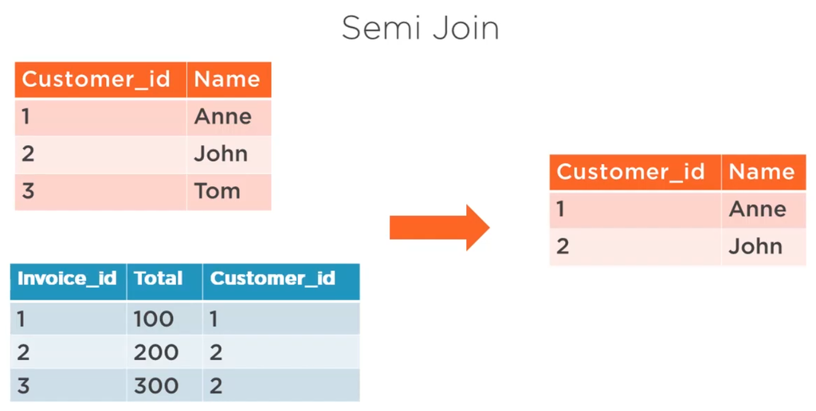

* Note: This is similar to an inner joins but… + Inner joins return all data from the shared attribute column of both of the data frames + While semi joins only return data from the shared attribute column of one of the data frames

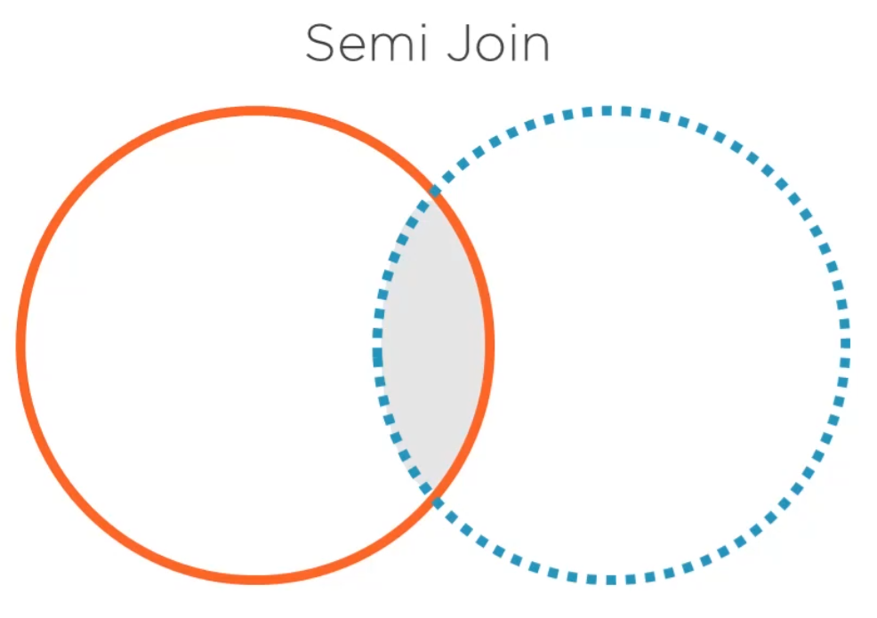

A Semi Join Illustration Image

```r
(customers <- data.frame(customer_id=1:3,
                         name=c('Anne', 'John', 'Tom')))
```

```
##   customer_id name
## 1           1 Anne
## 2           2 John
## 3           3  Tom
```

```r
(invoices <- data.frame(invoice_id=1:4,
                        total=c(100, 200, 300, 50),
                        customer_id=c(1, 2, 2, 3)))
```

```
##   invoice_id total customer_id
## 1          1   100           1
## 2          2   200           2
## 3          3   300           2
## 4          4    50           3
```

```r
# First note the result of the inner join
inner_join(customers, invoices, by = 'customer_id')
```

```
##   customer_id name invoice_id total
## 1           1 Anne          1   100
## 2           2 John          2   200
## 3           2 John          3   300
## 4           3  Tom          4    50
```

```r
# And now the result of the semi join
semi_join(customers, invoices, by = 'customer_id')
```

```
##   customer_id name
## 1           1 Anne
## 2           2 John
## 3           3  Tom
```

### Anti Joins

- The opposite of a semi join… returns only the non-common values in a data frame

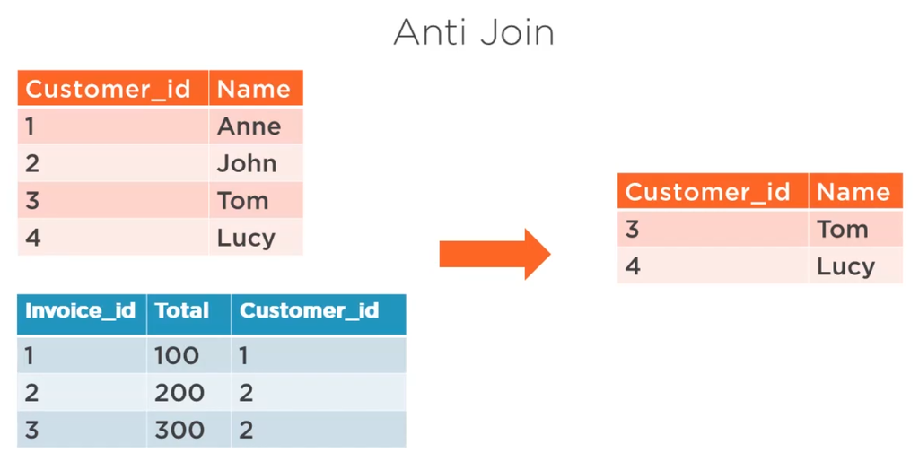

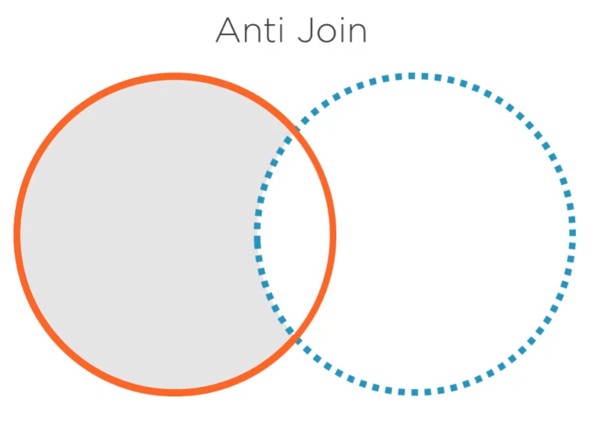

```r
(customers <- data.frame(customer_id=1:4,
                         name=c('Anne', 'John', 'Tom', 'Lucy')))
```

```
##   customer_id name
## 1           1 Anne
## 2           2 John
## 3           3  Tom
## 4           4 Lucy
```

```r
(invoices <- data.frame(invoice_id=1:3,
                        total=c(100, 200, 300),
                        customer_id=c(1, 2, 2)))
```

```
##   invoice_id total customer_id
## 1          1   100           1
## 2          2   200           2
## 3          3   300           2
```

```r
# First note the output of a semi join
semi_join(customers, invoices, by = 'customer_id')
```

```
##   customer_id name
## 1           1 Anne
## 2           2 John
```

```r
# And now the output of an anti join
anti_join(customers, invoices, by = 'customer_id')
```

```
##   customer_id name
## 1           3  Tom
## 2           4 Lucy
```

```r
# Note that if we combine the results of the semi and anti joins, we get the full customer data frame
customers
```

```
##   customer_id name
## 1           1 Anne
## 2           2 John
## 3           3  Tom
## 4           4 Lucy
```